# Modeling and prediction for movies

## Setup

### Load packages

```r
library(ggplot2)
library(dplyr)
library(statsr)
```

### Load data

```r
load("movies.Rdata")
```

## Part 1: Data

The data described in this project is 651 randomly selected movies which was made and realeased before 2016. This data set uses information from two website https://www.rottentomatoes.com/ and https://www.imdb.com/ for random sampling. Possible source of bias:

Generalizability: As discussed above, 651 randomly selected movies were the main data set. This does capture genelizability with a large number of movies, and this number is probably less than 10% of the total number of movies.

Causality: This is an observational study when each movie is investigated individually with no random assignment used. Hence, no causality can be established.

## Part 2: Research question

Perform multiple linear regression of imdb_rating: Rating on IMDB as a function of following parameters:

title_type: Type of movie (Documentary, Feature Film, TV Movie)

runtime: Runtime of movie,

thtr_rel_year: Year the movie is released in theaters

imdb_num_votes: Number of votes on IMDB, I transformed it into log10 scale for ease of calculation.

top200_box: Whether or not the movie is in the Top 200 Box Office list on BoxOfficeMojo (no, yes)

audience_rating: Categorical variable for audience rating on Rotten Tomatoes (Spilled, Upright)

critics_rating: Categorical variable for critics rating on Rotten Tomatoes (Certified Fresh, Fresh, Rotten)

## Part 3: Exploratory data analysis

Perform exploratory data analysis for the data of interest.

```r
load("movies.Rdata")
movies <- movies %>%
  filter(!is.na(title_type),!is.na(runtime),!is.na(thtr_rel_year),!is.na(imdb_rating),!is.na(top200_box))
movies %>%
  group_by(title_type) %>%
  summarise(count = n())  %>%
  filter(!is.na(title_type))
```

```
## # A tibble: 3 x 2
##   title_type   count
##   <fct>        <int>
## 1 Documentary     54
## 2 Feature Film   591
## 3 TV Movie         5
```

Here, we perform summary statistics of movies by title_type. Although it is not really associated with the linear regression model, it still gives some intuitions of the model.

```r
movies %>%
   summarise(mean_run=mean(runtime),median_run=median(runtime),min_run=min(runtime),max_run=max(runtime))
```

```
## # A tibble: 1 x 4
##   mean_run median_run min_run max_run
##      <dbl>      <dbl>   <dbl>   <dbl>
## 1     106.       103.     39.    267.
```

EDA of runtime in the data.

```r
movies %>%
  summarise(meanimdb_rating=mean(imdb_rating),stdimdb_rating=sd(imdb_rating),medianimdb_rating=median(imdb_rating),minimdb_rating=min(imdb_rating),maximdb_rating=max(imdb_rating))
```

```
## # A tibble: 1 x 5
##   meanimdb_rating stdimdb_rating medianimdb_rating minimdb_rating
##             <dbl>          <dbl>             <dbl>          <dbl>
## 1            6.49           1.08              6.60           1.90
## # ... with 1 more variable: maximdb_rating <dbl>
```

EDA of imdb_rating - this is an important result showing mean of the response variable in the linear regression described in the next session.

```r
movies <- movies %>%
  mutate(log10_votes=log10(imdb_num_votes))
movies %>%
  summarise(mean_votes=mean(log10_votes),std_votes=sd(log10_votes),median_votes=median(log10_votes),min_votes=min(log10_votes),max_votes=max(log10_votes))
```

```
## # A tibble: 1 x 5
##   mean_votes std_votes median_votes min_votes max_votes
##        <dbl>     <dbl>        <dbl>     <dbl>     <dbl>
## 1       4.22     0.726         4.18      2.26      5.95
```

EDA of log10(imdb_num_votes), also plays a role in the multiple variable regression model.

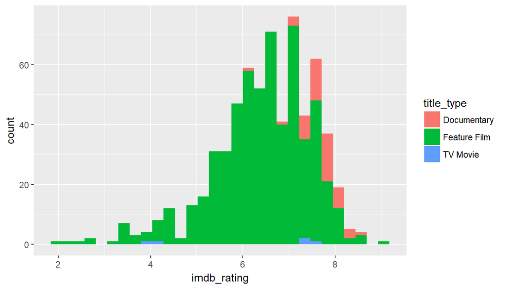

```r
ggplot(data = movies, mapping = aes(x = imdb_rating, fill = title_type)) + geom_histogram()
```

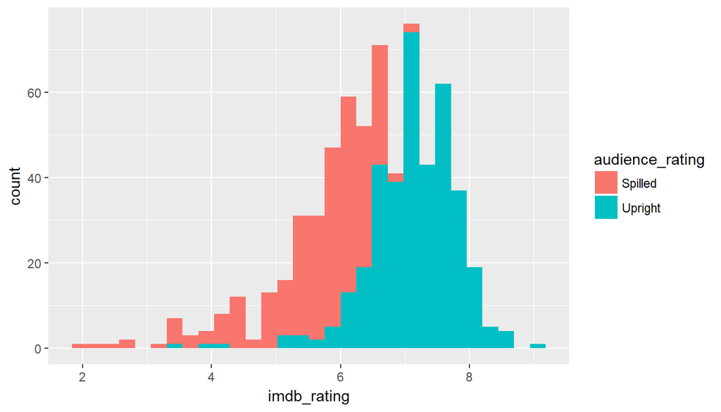

```r
ggplot(data = movies, mapping = aes(x = imdb_rating, fill = audience_rating)) + geom_histogram()
```

## Part 4: Modeling

Step 1: A Trial

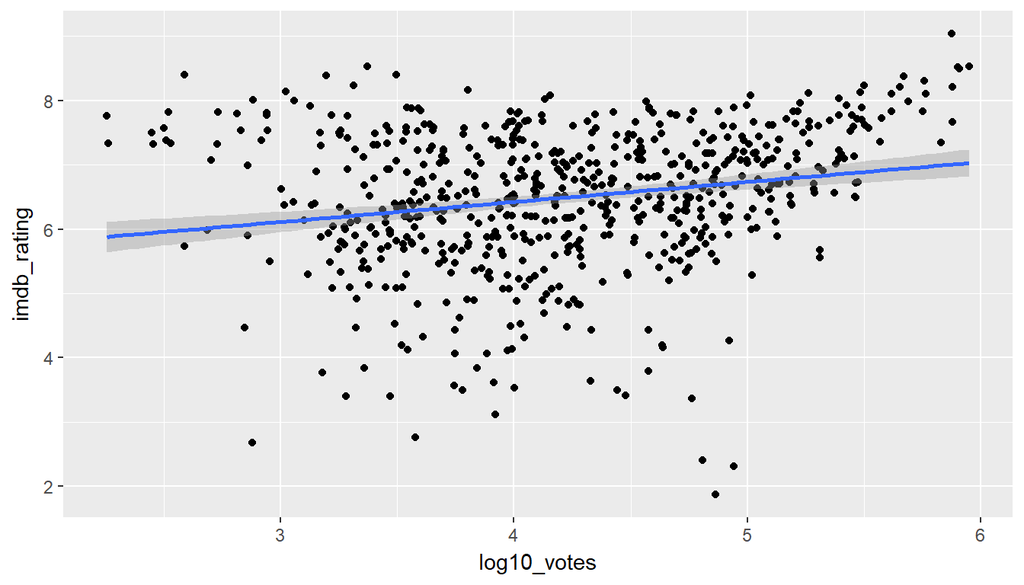

```r
movies <- movies %>%
  mutate(log10_votes = log10(imdb_num_votes))

ggplot(data = movies, mapping = aes( x = log10_votes, y= imdb_rating)) +
      geom_jitter() +
      geom_smooth(method = "lm")
```

This is a scatter plot of x=log10(imdb_num_votes) and imdb_rating with associating linear fit. The scatter points seem broad, showing weak linear dependency of this two parameters.

```r
m1 <- lm(imdb_rating ~ log10(imdb_num_votes), movies)
summary(m1)
```

```
##
## Call:
## lm(formula = imdb_rating ~ log10(imdb_num_votes), data = movies)
##
## Residuals:
##     Min      1Q  Median      3Q     Max
## -4.7930 -0.5272  0.0798  0.7251  2.4142
##
## Coefficients:
##                       Estimate Std. Error t value Pr(>|t|)
## (Intercept)            5.17997    0.24570  21.083  < 2e-16 ***
## log10(imdb_num_votes)  0.31102    0.05742   5.416 8.57e-08 ***
## ---
## Signif. codes:  0 '***' 0.001 '**' 0.01 '*' 0.05 '.' 0.1 ' ' 1
##
## Residual standard error: 1.062 on 648 degrees of freedom
## Multiple R-squared:  0.04331,    Adjusted R-squared:  0.04184
## F-statistic: 29.34 on 1 and 648 DF,  p-value: 8.575e-08
```

This section performs single variable regression model imdb_rating as a function of log10(imdb_num_votes), with associating residual plot. The R2 is 0.043.

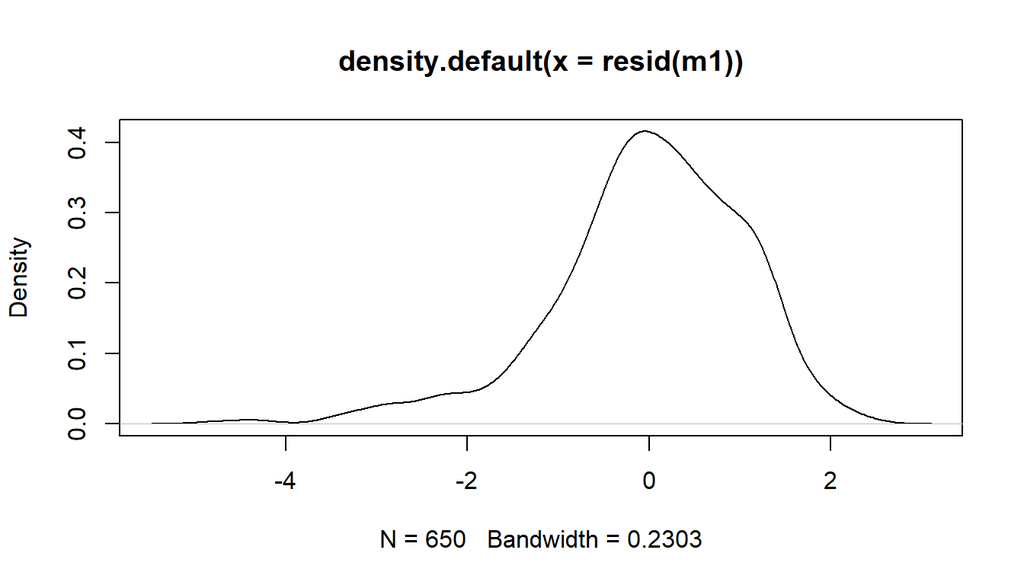

```r
plot(density(resid(m1)))
```

This is density plot of residual, showing a nearly normal distribution.

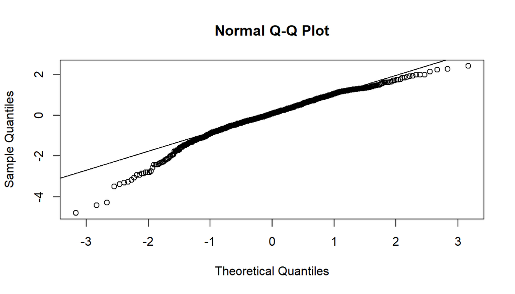

```r
qqnorm(resid(m1))
qqline(resid(m1))
```

This is quantile normal plot of residual.

We choose simple fitting linear model method, used to carry out regression.

```r
movies %>%
  summarise(cor(imdb_rating,runtime))
```

```
## # A tibble: 1 x 1
##   `cor(imdb_rating, runtime)`
##                         <dbl>
## 1                       0.268
```

Checking the correlation between imdb_rating and runtime: 0.27 which is non-negligble.

```r
m_full <- lm(imdb_rating ~ title_type+runtime + thtr_rel_year + log10(imdb_num_votes) + top200_box+audience_rating+critics_rating, data = movies)
summary(m_full)
```

```
##
## Call:
## lm(formula = imdb_rating ~ title_type + runtime + thtr_rel_year +
##     log10(imdb_num_votes) + top200_box + audience_rating + critics_rating,
##     data = movies)
##
## Residuals:
##     Min      1Q  Median      3Q     Max
## -3.6008 -0.2774  0.0614  0.4124  1.6166
##
## Coefficients:
##                         Estimate Std. Error t value Pr(>|t|)
## (Intercept)            15.932782   5.214533   3.055 0.002341 **
## title_typeFeature Film -0.919927   0.115822  -7.943 8.93e-15 ***
## title_typeTV Movie     -1.147958   0.307203  -3.737 0.000203 ***
## runtime                 0.007976   0.001406   5.674 2.12e-08 ***
## thtr_rel_year          -0.005405   0.002608  -2.073 0.038603 *
## log10(imdb_num_votes)   0.278129   0.047221   5.890 6.24e-09 ***
## top200_boxyes          -0.200921   0.177309  -1.133 0.257568
## audience_ratingUpright  0.934911   0.063451  14.734  < 2e-16 ***
## critics_ratingFresh    -0.049411   0.080320  -0.615 0.538654
## critics_ratingRotten   -0.706370   0.082236  -8.590  < 2e-16 ***
## ---
## Signif. codes:  0 '***' 0.001 '**' 0.01 '*' 0.05 '.' 0.1 ' ' 1
##
## Residual standard error: 0.6511 on 640 degrees of freedom
## Multiple R-squared:  0.6447, Adjusted R-squared:  0.6397
## F-statistic: 129.1 on 9 and 640 DF,  p-value: < 2.2e-16
```

Adjusted R-squared is 0.6397 which is much better than previous single varialbe fit.

## Part 5: Prediction

First, we need to create a new data frame for a movie.

```r
newmovie <- data.frame(title_type="Feature Film",runtime=94,thtr_rel_year=2008,imdb_num_votes=110000, top200_box="no",audience_rating="Spilled",critics_rating="Fresh")
```

We take the data for this movie randomly, between max and min of the parameters involved. But the aim is to get a imdb_rating close to its mean or median. The detailed prediction will be presented below.

```r
predict(m1, newmovie)
```

```
##        1
## 6.747946
```

Here, we predict imdb_rating of newmovie. We obtain imdb_rating = 6.74, close to the median of imdb_rating.

Predict with confident level:

```r
predict(m1, newmovie, interval = "prediction", level = 0.95)
```

```
##        fit      lwr      upr
## 1 6.747946 4.659045 8.836848
```

Hence, the model predicts with 95% confident interval that the imdb_rating of newmovie is between 4.66 and 8.83.